# Ag-Analytics® - Harmonized Landsat-Sentinel Service

The Ag-Analytics® Harmonized Landsat-Sentinel Service (HLS) API provides the service in which a user can provide an area-of-interest (AOI) with additional customized options to retrieve the dynamics of their land at various times from the Landsat-8 and Sentinel-2 satellites. This service provides information on cloud cover, statistics, and Normalized Difference Vegetation Index in addition to MSI bands information.  
The Harmonized Landsat-Sentinel (HLS) Project is a NASA initiative to produce a Virtual Constellation (VC) of surface reflectance (SR) data from the Operational Land Imager (OLI) and MultiSpectral Instrument (MSI) onboard the Landsat-8 and Sentinel-2 remote sensing satellites, respectively. The data from these satellites creates unprecedented opportunities for timely and accurate observation of Earth status and dynamics at moderate (<30 m) spatial resolution every 2-3 days.

Experience the usage of this service on Ag-Analytics website using below link  
https://ag-analytics.portal.azure-api.net/docs/services/harmonized-landsat-sentinel-service/operations/hls-service

```python
import requests
import json
import time
from pandas.io.json import json_normalize
from collections import defaultdict
import pandas as pd
import zipfile, io
from IPython.display import Image

%matplotlib inline
%autosave 0
```

```
Autosave disabled
```

###### Request parameters details

Request URL: https://ag-analytics.azure-api.net/hls-service/

1) aoi (geometry, file/text, required): The structure of the geometry can be one of the following.  
i. JSON geometry objects returned by the arcgis rest api, (file/text) ii. GEOJSON (file/text) iii. Shapefile (file) iv. Raster of tiff extension (file)

2) Band (Spectral band name, list, required): Provide the list of HLS Spectral band names to retrieve for given aoi

4) resolution (cellsize in meters, float, optional):  
Default (0.0001)

5) Startdate (Date, mm/dd/yyyy, optional): Enter the starting date to capture the details from Landsat/Sentinel-2  
• Year in Startdate for Landsat should start from 2013  
• Year in Startdate for Sentinel should start from 2015  
• Note Startdate and Enddate both should be given, In the absence of other the service retrieves the latest information available on the land.

6) Enddate (Date, mm/dd/yyyy, optional): Enter the end date to capture the details from Landsat/Sentinel-2  
• Year in Enddate for Landsat can be till current year  
• Year in Enddate for Sentinel can be till current year  
• Note Startdate and Enddate both should be given, In the absence of other the service retrieves the latest information available on the land

7) byweek (int,boolean,optional):This parameter will mosaic the rasters in a week Default 1

In order to get Ocp-Apim-Subscription-Key, please click on this link https://ag-analytics.org/developer/Session/SignInFromPayment

### Request Parameters

```python
values={"aoi": '{"type":"Feature","geometry":{"type":"Polygon","coordinates":[[[-93.511545,42.071053],[-93.511565,42.074566],[-93.50667,42.074588],[-93.501908,42.074559],[-93.501936,42.071045],[-93.511545,42.071053]]]},"properties":{"OBJECTID":3350330,"CALCACRES":77.09999847,"CALCACRES2":null},"id":3350330}',
"Band": "['NDVI']",
"Enddate": "3/8/2019",
"Startdate": "3/2/2019",
"legendtype": "Relative",
"satellite": "Landsat,Sentinel",
"resolution":"0.00001",
"byweek":"1"}



headers={'Content-Type':'application/x-www-form-urlencoded','Ocp-Apim-Subscription-Key': 'xxxxxxxxxxxxxxxxxxxxxxxxxxxxxx'}
```

### API Function

```python
def harmonisedlandsatdata(values,headers):
    try:
        url = "https://ag-analytics.azure-api.net/hls-service/"


        response = requests.post(url, data=values,headers=headers).json()

        print(response)

        return response

    except Exception as e:
        print(e)
        raise e
```

### Calling API Function and Displaying Response

```python
hlsresponse=harmonisedlandsatdata(values,headers)
```

```
[{'Values': '', 'Xcoordinates': '', 'Ycoordinates': '', 'band': 'NDVI', 'download_url': 'downloads/raster_bandNDVI_date2019196-2019202_20190807_224634_3097.tif', 'error': '', 'features': [{'attributes': {'CellSize': [1e-05, -1e-05], 'CoordinateSystem': 'GEOGCS["WGS 84",DATUM["WGS_1984",SPHEROID["WGS…
```

### Displaying Output Image

```
Legend Values :  [{'Area': '0.91 %', 'Count': 2577, 'CountAllPixels': 282639, 'Max': 0.2587678168353666, 'Mean': 0.23697687801293443, 'Min': 0.21518593919050227, 'color': '#ff0000'}, {'Area': '1.86 %', 'Count': 5255, 'CountAllPixels': 282639, 'Max': 0.30234969448023097, 'Mean': 0.28055875565779875, …
```

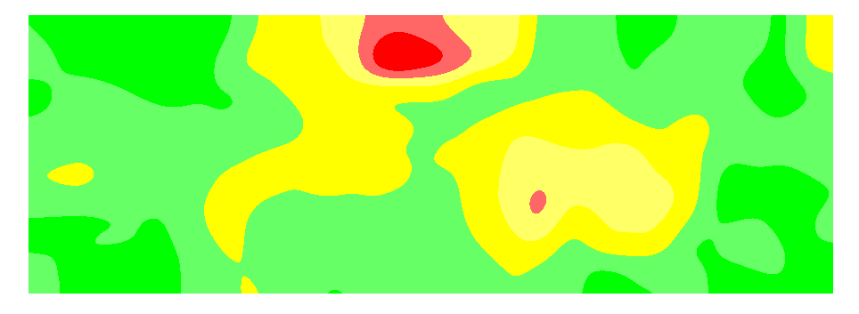

```python
for resp in hlsresponse:
    if resp["band"]=="NDVI" and resp["download_url"]!="":

        print("Legend Values : ",resp["features"][0]['attributes']['Legend'])

        img_uri=resp["features"][0]['attributes']["pngb64"]

        Image(url=img_uri)




Image(url=img_uri)
```